# Mapping US Vaccination Data in R

Michelle Chiu

7/14/2021

### Required Packages

```r
# uncomment below to install any missing packages as needed
# install.packages(c("readr", "tidyverse", "ggplot2", "viridis", "choroplethr", "maps"))

# load packages
library(readr)
library(tidyverse)
library(ggplot2)
library(viridis)
library(choroplethr)
library(choroplethrMaps)
library(maps)
```

### COVID-19 Vaccination Data

You can import the dataset **us_state_vaccinations.csv** from the data folder (downloaded on June 28, 2021) or download the most up-to-date version from [Data on COVID-19 vaccinations by Our World in Data](https://github.com/owid/covid-19-data).

#### Cleaning the data

Filter by ‘date’ and select the variables we will be plotting: ‘location’ and ‘people_fully_vaccinated_per_hundred’

```r
# read covid-19 dataset into R and assign it to an object
covid_raw <- read_csv("data/us_state_vaccinations.csv")
head(covid_raw)
```

```
## # A tibble: 6 x 14
##   date       location total_vaccinations total_distributed people_vaccinated
##   <date>     <chr>                 <dbl>             <dbl>             <dbl>
## 1 2021-01-12 Alabama               78134            377025             70861
## 2 2021-01-13 Alabama               84040            378975             74792
## 3 2021-01-14 Alabama               92300            435350             80480
## 4 2021-01-15 Alabama              100567            444650             86956
## 5 2021-01-16 Alabama                  NA                NA                NA
## 6 2021-01-17 Alabama                  NA                NA                NA
## # … with 9 more variables: people_fully_vaccinated_per_hundred <dbl>,
## #   total_vaccinations_per_hundred <dbl>, people_fully_vaccinated <dbl>,
## #   people_vaccinated_per_hundred <dbl>, distributed_per_hundred <dbl>,
## #   daily_vaccinations_raw <dbl>, daily_vaccinations <dbl>,
## #   daily_vaccinations_per_million <dbl>, share_doses_used <dbl>
```

```r
# filter by date and select relevant variables
today_covid <-
  covid_raw %>%
  filter(date=='2021-06-28') %>%
  select(location, people_fully_vaccinated_per_hundred)
head(today_covid)
```

```
## # A tibble: 6 x 2
##   location          people_fully_vaccinated_per_hundred
##   <chr>                                           <dbl>
## 1 Alabama                                          32.4
## 2 Alaska                                           42.7
## 3 American Samoa                                   37.7
## 4 Arizona                                          40.1
## 5 Arkansas                                         34.0
## 6 Bureau of Prisons                                NA
```

Read in the the US state map and assign it to an object **us_map**. The ‘long’ and ‘lat’ (longitude and latitude) columns will be used to generate our US state map.

```r
# map_data function from 'ggplot2' uses name of map provided by 'maps' package
# import us state map and assign it to an object
us_map <- map_data("state")
head(us_map) # peek at the us state map data
```

```
##        long      lat group order  region subregion
## 1 -87.46201 30.38968     1     1 alabama      <NA>
## 2 -87.48493 30.37249     1     2 alabama      <NA>
## 3 -87.52503 30.37249     1     3 alabama      <NA>
## 4 -87.53076 30.33239     1     4 alabama      <NA>
## 5 -87.57087 30.32665     1     5 alabama      <NA>
## 6 -87.58806 30.32665     1     6 alabama      <NA>
```

Next, we will tweak our **today_covid** dataframe to fit the format required for [state_choroplethr](https://arilamstein.com/documentation/choroplethr/reference/state_choropleth.html) function, then merge by ‘region’ to make our final dataframe **today_covid_map** that will be used in both [ggplot2](https://ggplot2.tidyverse.org/) and [choroplethr](https://arilamstein.com/packages/) map visuals.

```r
# convert states to lowercase to match reference map
today_covid$location <- tolower(today_covid$location)

# rename column names and ny state to match reference map
colnames(today_covid) <- c('region','value')
today_covid$region <-
  plyr::revalue(today_covid$region, c("new york state" = "new york"))

# merge vaccination data with map long/lat columns
today_covid_map <- merge(us_map, today_covid, by = "region")
```

### Mapping COVID-19 vaccination across the US

#### Using [ggplot2](https://ggplot2.tidyverse.org/)

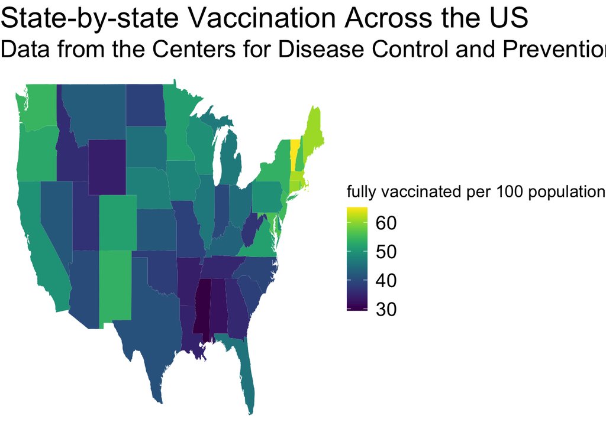

```r
ggplot_map <-
  ggplot(data = today_covid_map,
         aes(x = long, y = lat)) +
  geom_map(data = today_covid_map, map = us_map,
           aes(fill = value, map_id = region)) +
  scale_fill_viridis(name = "fully vaccinated per 100 population",
                     option = "D") +
  theme_void() +
  labs(title = "State-by-state Vaccination Across the US",
       subtitle = "Data from the Centers for Disease Control and Prevention (June 28th, 2021)") +
  theme(text = element_text(size = 20),
        legend.title = element_text(size = 14),
        legend.position = 'right')

ggplot_map
```

#### Using [choroplethr](https://arilamstein.com/documentation/choroplethr/reference/)

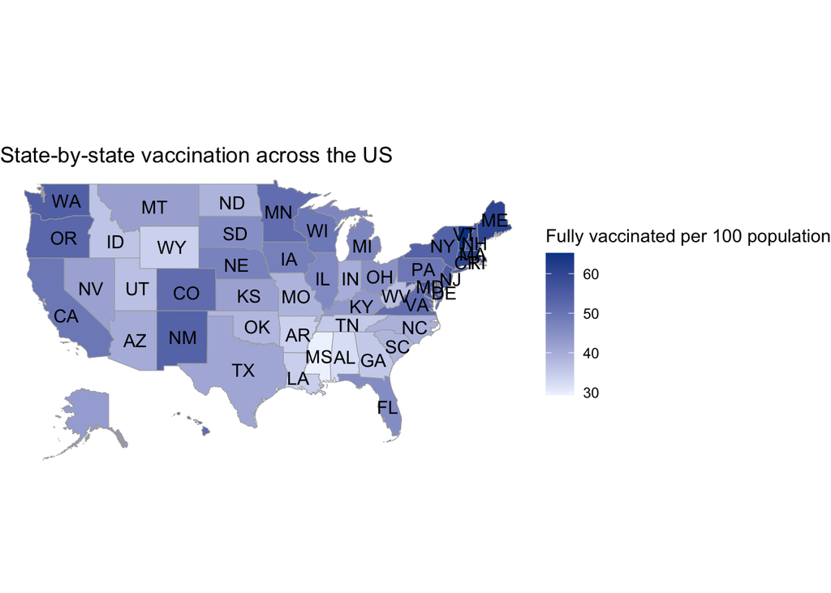

```r
# note that state_choropleth parameters do not require us_map
choroplethr_map <-
  state_choropleth(today_covid,
                   title = "State-by-state vaccination across the US",
                   legend = "Fully vaccinated per 100 population",
                   num_colors = 1)

choroplethr_map
```

```r
# 5 quantiles, zoom in on vector of states
# state_choropleth(today_covid, num_colors = 5,
#                  zoom = c("new york", "pennsylvania", "new jersey"))
```

### Built-in Challenge: Choose your own adventure

We’ll be using **state.x77** matrix built-in “state” data sets from Base R (R documentation [here](https://www.rdocumentation.org/packages/datasets/versions/3.6.2/topics/state)). Check out solution.R script in the project repository for one (possible) set of solutions for the challenge.

```r
# Take the state.x77 data
# plot using choroplethr or ggplot or both
# `Frost`, mean number of days with minimum temperature below freezing (1931-1960)
# or one of the other vars you find interesting!

# This is the state.x77 dataset
head(state.x77)
```

```
##            Population Income Illiteracy Life Exp Murder HS Grad Frost   Area
## Alabama          3615   3624        2.1    69.05   15.1    41.3    20  50708
## Alaska            365   6315        1.5    69.31   11.3    66.7   152 566432
## Arizona          2212   4530        1.8    70.55    7.8    58.1    15 113417
## Arkansas         2110   3378        1.9    70.66   10.1    39.9    65  51945
## California      21198   5114        1.1    71.71   10.3    62.6    20 156361
## Colorado         2541   4884        0.7    72.06    6.8    63.9   166 103766
```

```r
?state.x77

# You will need to reformat/shape it to be used to make a plot!
# As a reminder, this is what the today_covid dataset looked like:
head(today_covid)
```

```
## # A tibble: 6 x 2
##   region            value
##   <chr>             <dbl>
## 1 alabama            32.4
## 2 alaska             42.7
## 3 american samoa     37.7
## 4 arizona            40.1
## 5 arkansas           34.0
## 6 bureau of prisons  NA
```